# NHL Expected Goals Model

Ok now that we have the model ready to go and the fit of it is statistically significant over the null model it’s time to see how it fits our test data. I’ll be performing all the same steps to the test data to create the variables as I did the training data. I won’t go through all the steps again but if you want to see the code it will be in the google drive with the rest of the files.

So now that we have our test data ready to go we will predict the expected goal for each Fenwick attempt in our test data

```r
Test_Fenwick_Data$xG <- predict(xGmodel, Test_Fenwick_Data, type = "response")
```

Let’s graph our predictions at each location by the average xg Value to get a feel for our data.

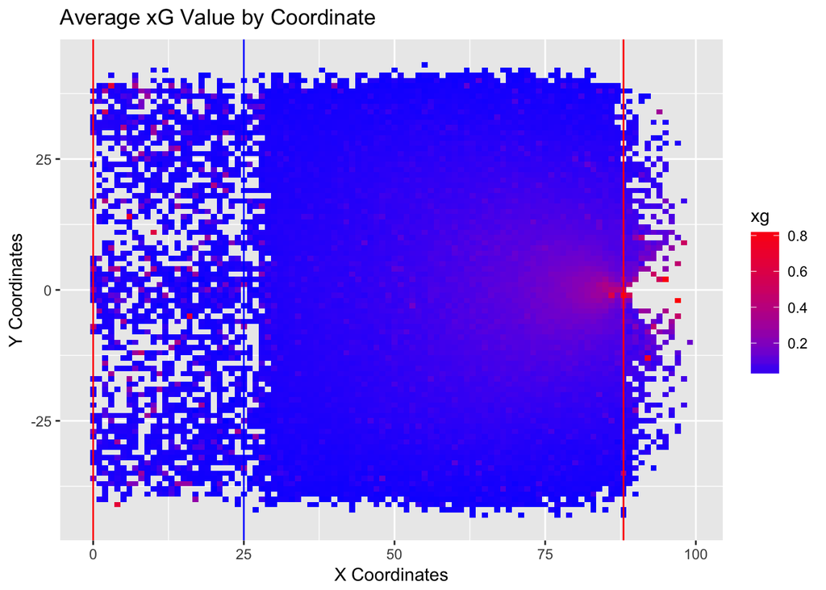

```r
avg_xG_by_coord <- Test_Fenwick_Data %>% group_by(coords_x, coords_y) %>%
    summarise(xg = mean(xG))

ggplot(avg_xG_by_coord, aes(coords_x, coords_y, fill = xg)) + geom_raster() +
    scale_fill_gradient(low = 'blue', high = 'red')+
    geom_vline(xintercept = 0, color = 'red') +
    geom_vline(xintercept = 25, color = 'blue') +
    geom_vline(xintercept = 88, color = 'red') +
    xlab('X Coordinates') + ylab('Y Coordinates') +
    labs(title = 'Average xG Value by Coordinate')
```

As you can see there are some weird outliers in the neutral zone. I’d assume these are caused by the inclusion of empty net goals in the prediction model. But other than that the plot seems to fit the intution that the closer to the goal and closer to the center of the ice a shooter is the greater chance of a shot turning into a goal. The next way to test the predictions of our model is to plot it’s [ROC curve](https://en.wikipedia.org/wiki/Receiver_operating_characteristic) and calculate the area underneath the curve. This will be accomplished with the `pROC` package in R.

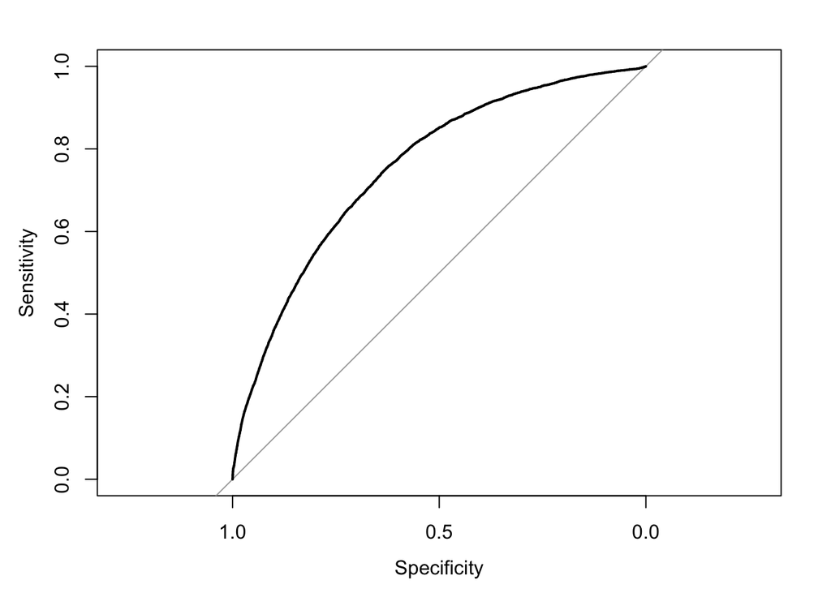

```r
g <- roc(is_goal ~ xG, data = Test_Fenwick_Data)
plot(g)
```

```r
auc(g)
```

```
## Area under the curve: 0.7556
```

You can read more info about interpereting the ROC curve from this [link,](http://gim.unmc.edu/dxtests/roc3.htm) but the gist of it is that the model is a fair model by this metric. It’s not a perfect model, but it’s not completely useless as well. But for the first attempt at a model it shows us that I’m working in the right direction and we have good foundation on which to build improvments on.

Ok lets to get to the fun stuff and see how individual players performed in the 2017 season by our model. I’m also going to plot each players xG total versus their goal total as another way to test the predictiveness of the model as well.

```r
#code to group xg and goals by player
xg_player <- Test_Fenwick_Data %>%
    group_by(event_player_1, event_team) %>%
    summarise( xG = sum(xG), Goals = sum(is_goal), Difference = sum(xG) - sum(is_goal))
head(xg_player)
```

```
## # A tibble: 6 x 5
## # Groups:   event_player_1 [6]
##    event_player_1 event_team          xG Goals  Difference
##             <chr>      <chr>       <dbl> <dbl>       <dbl>
## 1    AARON.EKBLAD        FLA 11.02887921    10  1.02887921
## 2      AARON.NESS        WSH  0.02557414     0  0.02557414
## 3 ADAM.CLENDENING        NYR  1.35385413     2 -0.64614587
## 4  ADAM.CRACKNELL        DAL  8.22744066    10 -1.77255934
## 5       ADAM.ERNE        T.B  3.54879312     3  0.54879312
## 6   ADAM.HENRIQUE        N.J 18.51550598    20 -1.48449402
```

```r
arrange(xg_player, desc(xG))
```

```
## # A tibble: 941 x 5
## # Groups:   event_player_1 [880]
##      event_player_1 event_team       xG Goals Difference
##               <chr>      <chr>    <dbl> <dbl>      <dbl>
##  1     JEFF.SKINNER        CAR 34.58222    37  -2.417784
##  2  AUSTON.MATTHEWS        TOR 34.00383    40  -5.996170
##  3     JOHN.TAVARES        NYI 33.65972    28   5.659719
##  4   CONNOR.MCDAVID        EDM 33.59372    30   3.593719
##  5   WAYNE.SIMMONDS        PHI 33.41914    31   2.419142
##  6      COREY.PERRY        ANA 30.50376    19  11.503756
##  7      RYAN.KESLER        ANA 30.48985    22   8.489851
##  8     JOE.PAVELSKI        S.J 30.47975    28   2.479749
##  9 NATHAN.MACKINNON        COL 29.61119    16  13.611189
## 10 PATRICE.BERGERON        BOS 29.60397    21   8.603967
## # ... with 931 more rows
```

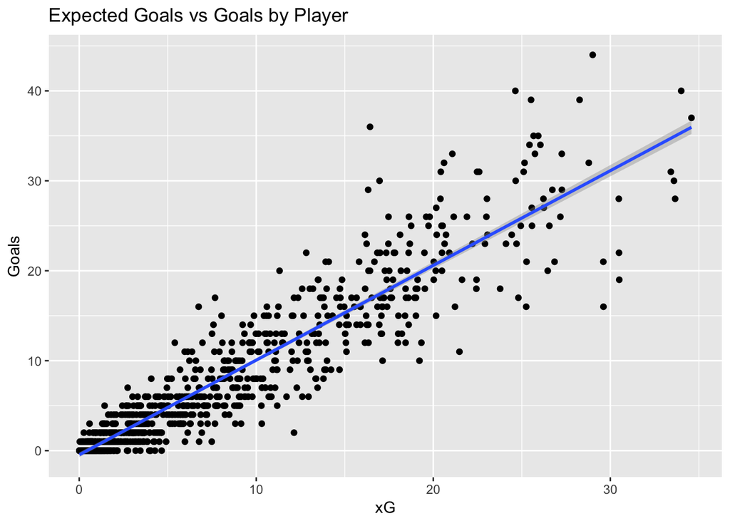

```r
ggplot(aes(x = xG, y = Goals), data = xg_player) +
    geom_point() +
    geom_smooth(method = 'lm') +
    labs(title = 'Expected Goals vs Goals by Player')
```

```r
play_xg <- lm(Goals ~ xG, data = xg_player)
summary(play_xg)
```

```
##
## Call:
## lm(formula = Goals ~ xG, data = xg_player)
##
## Residuals:
##      Min       1Q   Median       3Q      Max
## -14.7164  -1.2687   0.0663   0.9677  19.1669
##
## Coefficients:
##             Estimate Std. Error t value Pr(>|t|)
## (Intercept) -0.46500    0.13777  -3.375 0.000768 ***
## xG           1.05303    0.01334  78.930  < 2e-16 ***
## ---
## Signif. codes:  0 '***' 0.001 '**' 0.01 '*' 0.05 '.' 0.1 ' ' 1
##
## Residual standard error: 3.044 on 939 degrees of freedom
## Multiple R-squared:  0.869,  Adjusted R-squared:  0.8689
## F-statistic:  6230 on 1 and 939 DF,  p-value: < 2.2e-16
```

As seen with the graph and the regression line the xG model works very well in predicting individual goal totals based on the inputs from the data. But as the graph shows the greatest variance in our data of predicted versus actual is when the data approaches the extremes of the higher end. Now let’s take a look at a team level

```r
xg_team <- Test_Fenwick_Data %>%
    group_by(event_team) %>%
    summarise( xG = sum(xG), Goals = sum(is_goal), Difference = sum(xG) - sum(is_goal))

arrange(xg_team, desc(xG))
```

```
## # A tibble: 30 x 4
##    event_team       xG Goals Difference
##         <chr>    <dbl> <dbl>      <dbl>
##  1        TOR 261.5669   248  13.566932
##  2        PIT 260.5818   269  -8.418173
##  3        CAR 253.6819   212  41.681865
##  4        EDM 251.0783   241  10.078280
##  5        ANA 242.3017   218  24.301721
##  6        NYR 242.1009   253 -10.899078
##  7        DAL 238.9408   221  17.940751
##  8        CBJ 234.6076   247 -12.392359
##  9        BOS 233.8284   231   2.828355
## 10        NYI 231.9795   239  -7.020528
## # ... with 20 more rows
```

```r
team_xg <- lm(Goals ~ xG, data = xg_team)
summary(team_xg)
```

```
##
## Call:
## lm(formula = Goals ~ xG, data = xg_team)
##
## Residuals:
##     Min      1Q  Median      3Q     Max
## -44.583 -13.017  -1.734  14.759  39.242
##
## Coefficients:
##             Estimate Std. Error t value Pr(>|t|)
## (Intercept)  15.8002    48.1668   0.328  0.74533
## xG            0.9178     0.2137   4.295  0.00019 ***
## ---
## Signif. codes:  0 '***' 0.001 '**' 0.01 '*' 0.05 '.' 0.1 ' ' 1
##
## Residual standard error: 20.76 on 28 degrees of freedom
## Multiple R-squared:  0.3972, Adjusted R-squared:  0.3756
## F-statistic: 18.45 on 1 and 28 DF,  p-value: 0.0001897
```

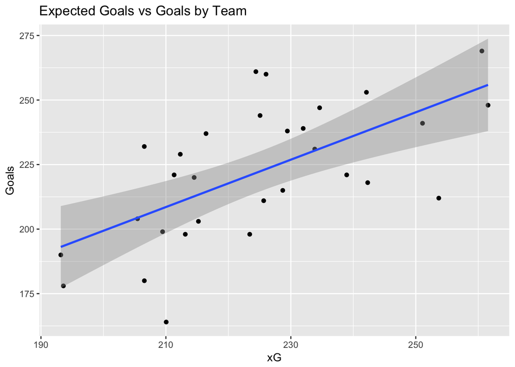

```r
ggplot(aes(x = xG, y = Goals), data = xg_team) +
    geom_point() +
    geom_smooth(method = 'lm') +
    labs(title = 'Expected Goals vs Goals by Team')
```

At the team level the xG model isn’t near as good at predicting goals as at the individual. I would expect this comes from the high variance from the higher end of the xG/Goal spectrum. The differences add up to drive the team xG amounts further away from the actual goal amounts leading to a worse correlation.

## Conclusions

I believe with this model I have created a method of reasonably predicting the probability of whether a shot on average will be a goal or not give our inputs. Is it a perfect model? No, not by any means but it is a good start towards building something more complex and maybe more accurate. One way could be including some form of shooter and/or goalie talent evaluator that would help improve things. Despite that though the model created did have a decent level of success by our various tests.

Again all of these performance metrics were run on the test data set which the model was not influenced by at all. I think one of the main things with this metirc is one can see whether teams and players are playing above or below their probabilites given the results versus their expected results.

Where there is a large difference one way or the other one could reasonably expect a team to regress to the mean at some point in the future, and if there is no sign of regression look deeper to see what other factors than what are included in the model could be affecting team and player goal outputs. Things such as injuries, playing time, and level of teammates all could affect the number of high level probability shots a player is attempting.

A couple things about what this model does not do as well. It does not predict what are the likely goal outputs of a player going forward. Tests could be run to see if there are intra and inter season repeatabilities at a player level which given the model’s predictive level’s at an individual level I would expect there would be. Then combined with an aging curve and some form of regression to the mean I think a reasonable model could be created. But as of right now I would not be confident in using this model in that capacity at all.

Again all the files of code, data, and model will be in the Google drive folder linked to earlier.

## Sources

Obviously I didn’t come up with this all on my own. All the writers of these articles were highly influential in the decisions made in creating this model and without them it wouldn’t have turned out as well as it did. So all the credit to these writers for making the path a lot easier for me.

[Emmanuel Perry’s xG Model](http://www.corsica.hockey/blog/2016/03/03/shot-quality-and-expected-goals-part-i/)

[DTMAboutHeart xG Model](https://hockey-graphs.com/2015/10/01/expected-goals-are-a-better-predictor-of-future-scoring-than-corsi-goals/)

[LAEGAP Methodology](http://hockeymetrics.net/laegap-methodology/)

[NHL Shot Quality by Ken Krzywicki](http://hockeyanalytics.com/Research_files/SQ-RS0910-Krzywicki.pdf)

[Evaluating NHL Goalies, Skaters, and Teams using Weighted Shots](https://arxiv.org/pdf/1205.1746.pdf)

[eGF Finally Fully Explained](http://xtrahockeystats.com/wordpress/?p=70)